# Asking Better Questions

# Question writing

- How do we minimize measurement error in surveys?
- What are some common problems with survey questions?

## Cognitive Strategies

- Optimizing is a decision making strategy where people systematically select the “best” option from a list of choices.
- Satisficing is a decision making strategy where people choose things that are “good enough” rather than optimal.

## How respondents answer questions

Optimizing:

1. Comprehension
2. Memory search
3. Summarization
4. Translation

Satisficing:

- Agree with everything
- Say you “don’t know”
- Pick at random
- Select the first answer

## How respondents answer questions

- People are “cognitive misers”, they don’t want to expend more mental energy than necessary.
- Surveys ask a lot of people for very little reward.

[figure not shown]

## How respondents answer questions

Some strategies to minimize satisficing:

- Group questions by topic.
- Use simple language and avoid ambiguity.
- Keep surveys short.
- Put sensitive questions towards the end.
- Avoid asking questions that are not relevant to the respondent.

# Problematic Questions

How could we improve this question?

> Question: *Do you support or oppose restoring the Joint Comprehensive Plan of Action (JCPOA) with Iran?* (Answers range from strongly support to strongly oppose)

## Problematic Questions: lack of context

- Even people who are familiar with the deal may not know the formal name, the “Iran nuclear deal” might be more common.
- If feasible, a description of the policy may be more useful than just the name.

[figure not shown]

[Yougov Iran nuclear deal question](https://today.yougov.com/politics/articles/12877-most-americans-now-support-iran-deal)

# Problematic Questions

*Are we spending too much money on welfare and national defense, or not enough?* (Answers range from “too little” to “too much”)

## Problematic Questions: double-barreled

- I might want to spend more on welfare and less on national defense, or vice versa.
- At a minimum, we probably want to split these up. (The General Social Survey asks a whole series of spending questions like this)

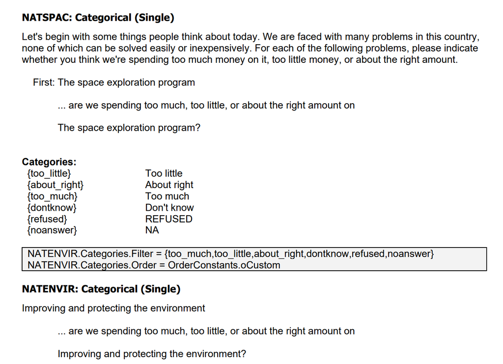

[GSS Spending Questions](https://gss.norc.org/get-documentation/questionnaires.html)

# Problematic Questions

*Have you ever joined a political protest?* (options are “I have done this”, “I might do this”, or “I would never do this”)

## Problematic Questions: non-exclusive categories

- These response options aren’t clearly mutually exclusive: I may have participated in the past but be unwilling to do so in the future. Or vice-versa.
- Splitting this up or adding a full range of options could be better.

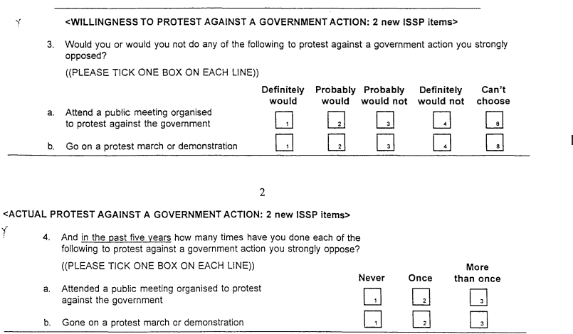

[Question from the 1992 ISSP](https://www.gesis.org/en/issp)

# Problematic Questions

*How often do you drink alcohol?* (options range from “Never” to “Frequently”)

## Problematic Questions: ambiguous time frames

- Respondents can interpret the relevant time frame differently. Lifetime? In the last week?
- Specifying some time frame can give you more consistent answers.

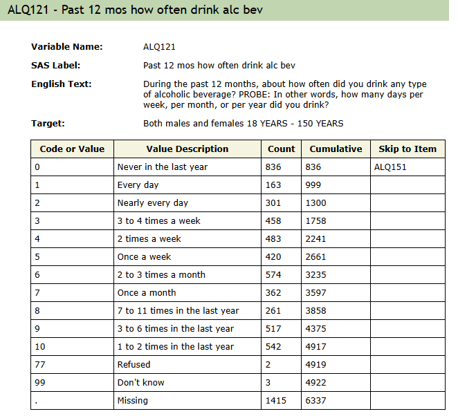

[Question from NHANES](https://wwwn.cdc.gov/Nchs/Data/Nhanes/Public/2021/DataFiles/ALQ_L.htm#ALQ111)

# Problematic Questions

*In the last six months, have you been a victim of a crime?* (options are “yes” or “no”)

## Problematic Questions: context and recall

- Respondents may not see themselves as victims, may forget minor crimes, or may not immediately think of even major crimes as “criminal”.
- Surveys like the NCVS use examples and ask about specific aspects of each crime.

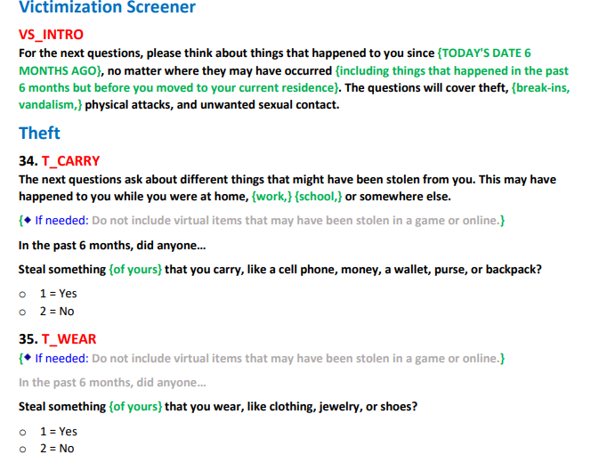

[NCVS alternative theft questions](https://bjs.ojp.gov/document/NCVS_Redesign_Questionnaire.pdf)

# Problematic Questions

*Do you abuse illegal drugs?* (responses are “yes” or “no”)

## Problematic Questions: loaded language

- Explicitly referencing loaded terms can make people less willing to give honest answers, especially on sensitive questions.
- Respondents may genuinely not consider themselves drug abusers.

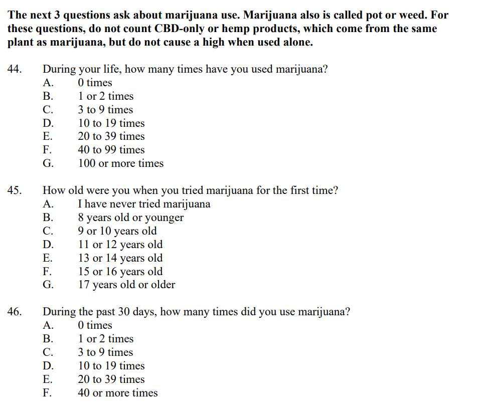

[Marijuana questions on the Youth Risk Behavior Survey](https://www.cdc.gov/yrbs/questionnaires/index.html)

# Problematic Questions

*Do you blame Democrats for the government shutdown?* (Answers are “Yes”, “No”, “Not sure”)

## Problematic Questions: leading

- Mentioning one party here is likely to nudge respondents toward blaming Democrats
- The response options would fail to capture the possibility of assigning equal blame to both parties.

[figure not shown]

[Yougov’s shutdown question](https://today.yougov.com/topics/politics/survey-results/daily/2025/11/10/2927c/2)

# Question writing

There are no hard and fast rules here, sometimes a flawed question is still the best possible option, but there are some general best practices

# Question writing

- Avoid ambiguous or emotionally charged language, especially when asking about a sensitive topic.
- Provide context where needed, and choose familiar names instead of jargon.
- Be specific about time frames.
- Offer response options that are exhaustive and mutually exclusive.
- Ask questions that only measure one “thing” at a time.
- Keep things short.

# Question writing

Where possible, you should try to use an established measure instead of reinventing the wheel.

- [General Social Survey](https://gss.norc.org/)
- [EuroBarometer](https://europa.eu/eurobarometer/)
- [American National Election study](https://electionstudies.org/)
- [National Health and Nutrition Examination Study](https://wwwn.cdc.gov/nchs/nhanes/)
- [World Values Survey](https://www.worldvaluessurvey.org/)
- [National Crime Victimization Study](https://bjs.ojp.gov/data-collection/ncvs)
- [U.S. Census/American Community Survey](https://www.census.gov/programs-surveys/acs.html)
- [Consumer Expenditure Survey](https://www.bls.gov/cex/csxsurveyforms.htm)

# How respondents think about questions

## Social Desirability

Everyone wants to be liked. Respondents will give answers that make them look good. Maybe even subconsciously.

### Social Desirability: voting

- As many as half of non-voters will claim to have voted in survey questions.
- (Hanmer et al. 2014) randomly gave subtle and unsubtle hints that researchers might check voter roles.

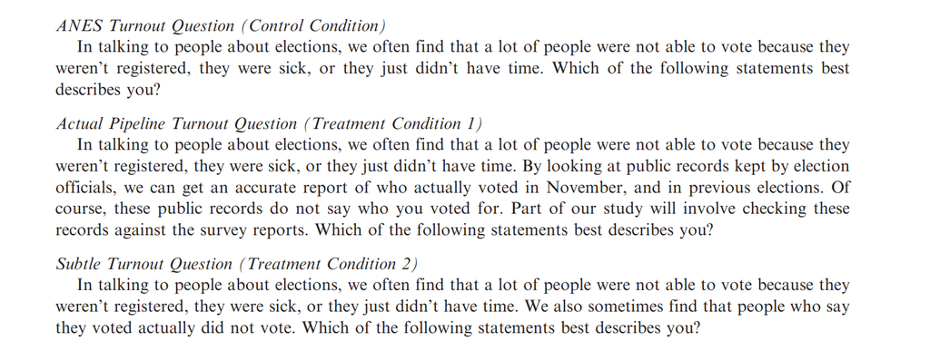

### Social Desirability: voting

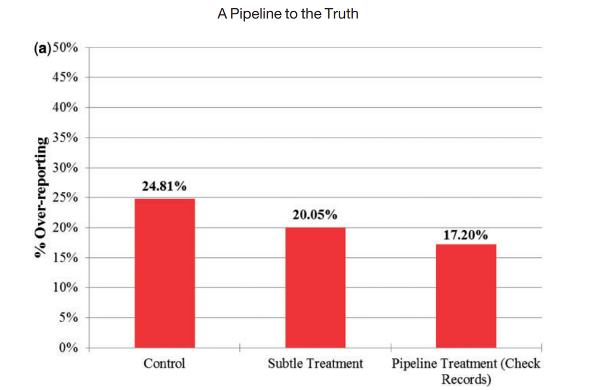

(Hanmer et al. 2014)

### Social Desirability: list-experiments

List-experiments are another option for dealing with sensitive topics by indirectly measuring preferences.

### Social Desirability: list-experiments

- Respondents are randomly assigned to receive only non-sensitive items, or non-sensitive items plus one sensitive question.
- They only say how many items they agree with.

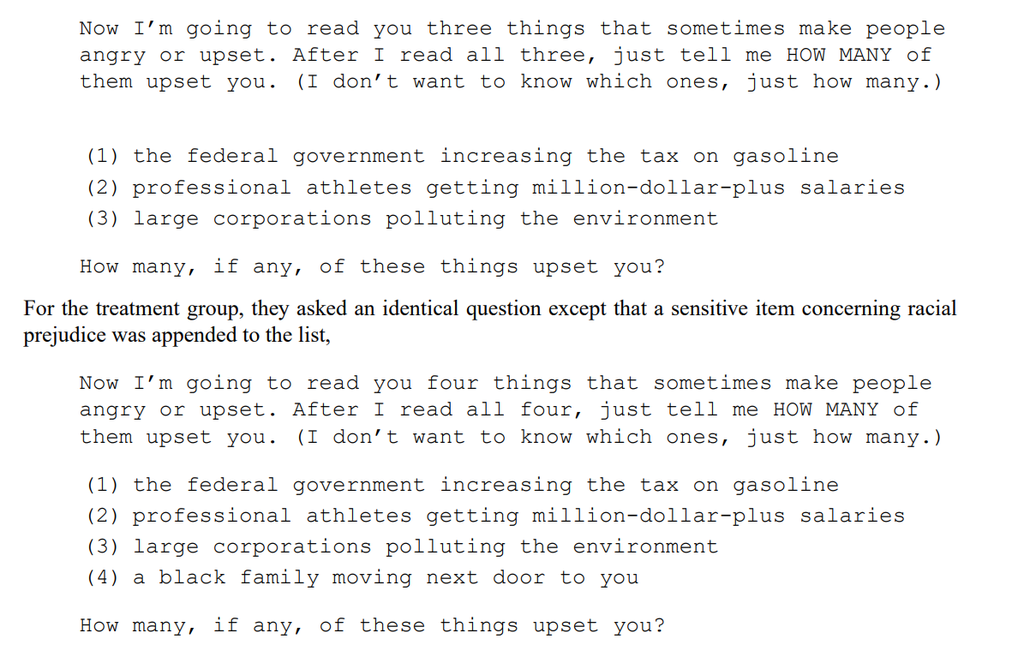

(Kuklinski et al. 1997)

### Social Desirability: list-experiments

- The difference in the average count of items is used to estimate support.

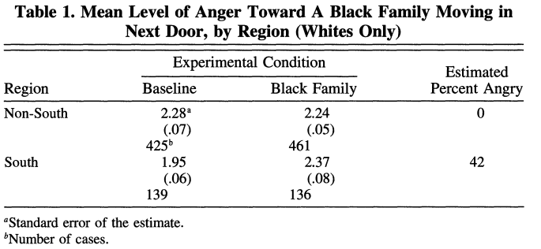

(Kuklinski et al. 1997)

### Social Desirability: some fixes

- Taking the interviewer out seems to help a lot! This is less of a problem on online surveys.
- Deliberately loading questions is another option (see the example marijuana question from the YRBSS)
- For highly sensitive topics, list experiments can mitigate the problem.

## Fence siting

- Some respondents may always pick the “neutral” option, if one is available.
- One option is to eliminate the neutral option all together, but there’s a trade-off here: some people genuinely don’t have an opinion!

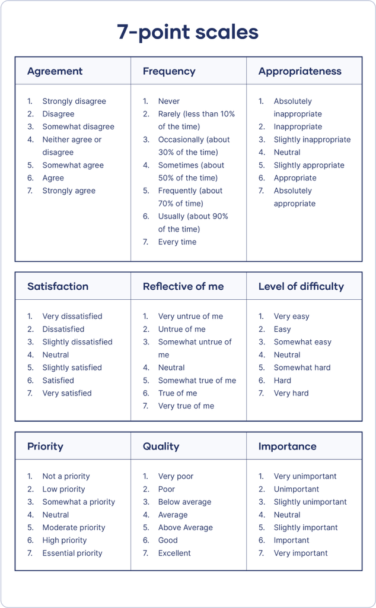

## Acquiescence/naysaying

- Some respondents may be prone to agree or disagree with everything. This could be because of their personality or a lack of attention.

### Acquiescence/naysaying: F-scale

- The F-scale was developed out of an early effort to understand the psychology of rank and file fascists.
- 30 agree/disagree items, with agreement indicating more authoritarian views.
- Acquiescence bias would probably inflate the estimates of authoritarian attitudes.

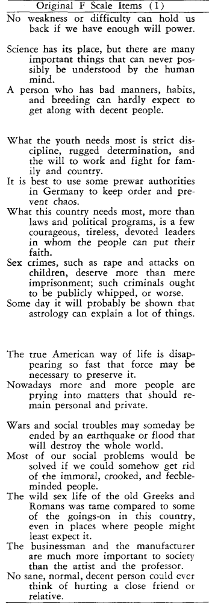

### Acquiescence/naysaying: some fixes

- Balanced agree/disagree items: agreement could = more of a characteristic in some questions, and less of it in others. (“you can’t trust strangers” and “most people are honest”)
- Forced choice: instead of agree/disagree, use either/or (“is it better to be obedient or creative?”) or some other item-specific options (“always - never”, “many - none”, etc.)

## Careless responding

- Respondents may get worn out, bored, or not really care to give accurate answers.
- (this can be especially problematic for surveys that offer rewards for respondents.)

### Careless responding

- In a 2022 online opt-in survey, Pew found that 5% of adults said they were licensed to operate a nuclear submarine.
- The actual number would round to 0%

[figure not shown]

[Pew](https://www.pewresearch.org/short-reads/2024/03/05/online-opt-in-polls-can-produce-misleading-results-especially-for-young-people-and-hispanic-adults/)

### Careless responding: some fixes

- Limiting the number of questions can help mitigate boredom.
- Including some attention screens (questions with clear answers that disqualify inattentive respondents) or scales with some reverse-coded items.

# Multi-item measures

- Complex concepts often require more than one thing to measure appropriately.
- This can reduce measurement error, but it also gives us some options for validating measurements.

## Racial resentment

- Reported “old-fashioned” racism declined precipitously after the Civil Rights movement.
- But most Americans continued to oppose programs designed to improve racial equality.
- Symbolic racism (or racial resentment, or modern racism) is a proposed explanation for this phenomenon.

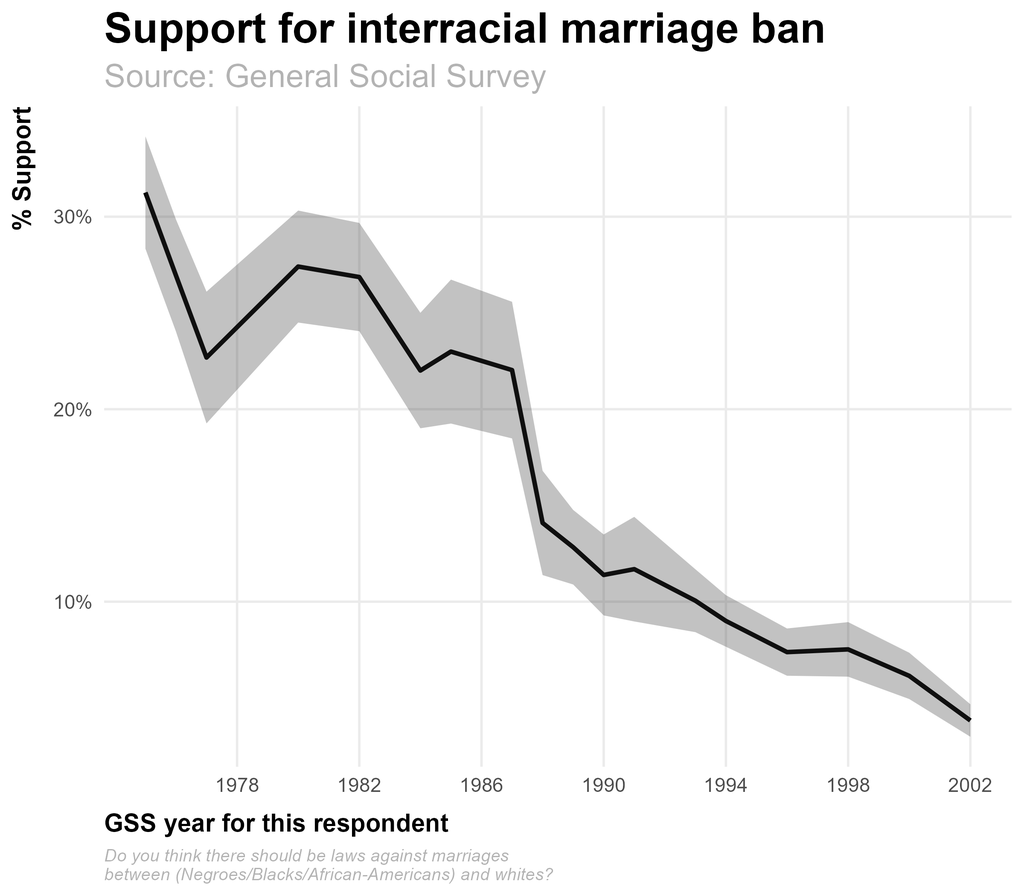

### Symbolic Racism

- “racial discrimination is no longer a serious obstacle to blacks’ prospects for a good life”
- “blacks’ continuing disadvantages are largely due to their unwillingness to work hard enough.”
- “As a result, both their continuing demands and increased advantages are unwarranted”

Scale: [Symbolic Racism 2000 scale](https://condor.depaul.edu/~phenry1/SR2Kinstructions.htm)

(Henry and Sears 2002)

### Symbolic Racism: Critiques

Some major critiques:

- Questions are tautological
- The questions mostly just measure conservatism.
- The construct isn’t really distinct from old-fashioned racism.

### Discussion reading: measuring support for political violence

[figure not shown]

### Discussion reading: measuring support for political violence

- Surveys indicate that a non-negligible minority of the U.S. public endorses political violence in surveys. (Carey et al. 2020)
- There’s a strong correlation between the strength of partisan identity and support for violence. (Kalmoe and Mason 2022)

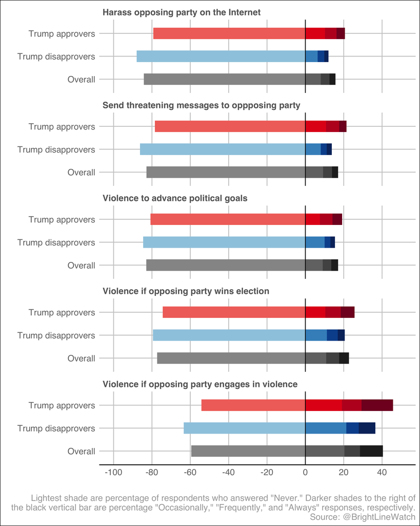

### Discussion reading: measuring support for political violence

However! Some researchers have criticized these questions as too abstract to elicit reliable responses, especially from disengaged respondents. (Westwood et al. 2022)

[figure not shown]

### Discussion reading: measuring support for political violence

> *“How much do you feel it is justified for [respondent’s own party] to use violence in advancing their political goals these days? (*Never, Occasionally, Frequently, Always*)*
- “Violence” is not defined.
- Nor are “political goals”.
- The response options lack a “neutral midpoint” or “don’t know” choice.

### Discussion reading: measuring support for political violence

- Disengaged respondents tend to report higher support for political violence.
- Questions that ask for more cognitive energy have a bigger disparity between engaged and disengaged respondents.

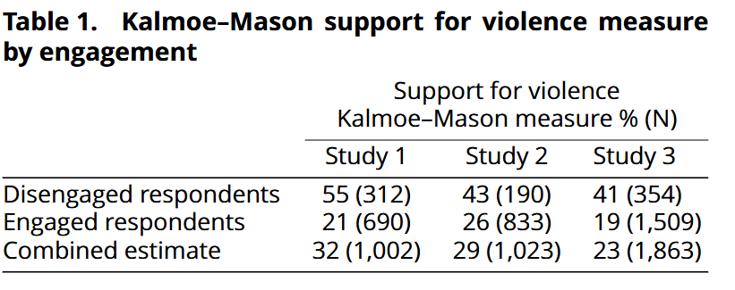

(Westwood et al. 2022)

### Discussion reading: measuring support for political violence

- How can we reduce the amount of satisficing in measuring political violence?
- How can we say one measure is better than any other?

## References

Carey, J. M., G. Helmke, and S. C. Stokes. 2020. “American Democracy on the Eve of the 2020 Election.” In *Bright Line Watch*. https://brightlinewatch.org/american-democracy-on-the-eve-of-the-2020- election/.

Hanmer, Michael J, Antoine J Banks, and Ismail K White. 2014. “Experiments to Reduce the over-Reporting of Voting: A Pipeline to the Truth.” *Political Analysis* 22 (1): 130–41.

Henry, Patrick J, and David O Sears. 2002. “The Symbolic Racism 2000 Scale.” *Political Psychology* 23 (2): 253–83.

Kalmoe, Nathan P, and Lilliana Mason. 2022. *Radical American Partisanship: Mapping Violent Hostility, Its Causes, and the Consequences for Democracy*. University of Chicago Press.

Kuklinski, James H, Paul M Sniderman, Kathleen Knight, et al. 1997. “Racial Prejudice and Attitudes Toward Affirmative Action.” *American Journal of Political Science*, 402–19.

Westwood, Sean J, Justin Grimmer, Matthew Tyler, and Clayton Nall. 2022. “Current Research Overstates American Support for Political Violence.” *Proceedings of the National Academy of Sciences* 119 (12): e2116870119.